# Capstone Project NLP

```python
import warnings
import pandas as pd
import numpy as np
import seaborn as sns
import matplotlib.pyplot as plt
import string
import nltk
import tensorflow as tf
from datetime import datetime
from nltk.corpus import stopwords
from nltk.stem import WordNetLemmatizer,PorterStemmer
from nltk.tokenize import word_tokenize
from wordcloud import WordCloud, STOPWORDS
from sklearn.model_selection import train_test_split
from sklearn.feature_extraction.text import CountVectorizer, TfidfVectorizer
from sklearn.metrics import accuracy_score, confusion_matrix, classification_report
from sklearn.svm import LinearSVC
from sklearn.ensemble import RandomForestClassifier, GradientBoostingClassifier
from xgboost import XGBClassifier
from tensorflow.keras.models import Model, Sequential, load_model
from tensorflow.keras.layers import Flatten, Activation, Dense, LSTM, Embedding, Dropout, Bidirectional, GlobalMaxPool1D
from tensorflow.keras.optimizers import SGD
from tensorflow.keras.callbacks import ReduceLROnPlateau, EarlyStopping, ModelCheckpoint, TensorBoard
from tensorflow.keras.preprocessing.sequence import pad_sequences
from tensorflow.keras.preprocessing.text import Tokenizer
from tensorflow.keras.initializers import Constant
import pickle

%matplotlib inline
```

```python
# Downloading the necessary libraries
nltk.download('punkt')
nltk.download('wordnet')
nltk.download('stopwords')
```

```
True
```

```python
# Ignore the warnings
warnings.filterwarnings("ignore")
```

## 1. Importing and warehousing the data

```python
# Reading the data
data_raw =  pd.read_csv('Data Set - industrial_safety_and_health_database_with_accidents_description.csv')
```

```python
# Displaying the shape of the data
data_raw.shape
```

```
(425, 11)
```

```python
# Displaying the size of the dataset
data_raw.size
```

```
4675
```

```python
# Displaying the attribute information
data_raw.info()
```

```
<class 'pandas.core.frame.DataFrame'>
RangeIndex: 425 entries, 0 to 424
Data columns (total 11 columns):
 #   Column                    Non-Null Count  Dtype
---  ------                    --------------  -----
 0   Unnamed: 0                425 non-null    int64
 1   Data                      425 non-null    object
 2   Countries                 425 non-null    object
 3   Local                     425 non-null    object
 4   Industry Sector           425 non-null    object
 5   Accident Level            425 non-null    object
 6   Potential Accident Level  425 non-null    object
 7   Genre                     425 non-null    object
 8   Employee or Third Party   425 non-null    object
 9   Critical Risk             425 non-null    object
 10  Description               425 non-null    object
dtypes: int64(1), object(10)
memory usage: 36.6+ KB
```

```python
# Displaying the head of the dataset
data_raw.head()
```

|  | Unnamed: 0 | Data | Countries | Local | Industry Sector | Accident Level | Potential Accident Level | Genre | Employee or Third Party | Critical Risk | Description |
| --- | --- | --- | --- | --- | --- | --- | --- | --- | --- | --- | --- |
| 0 | 0 | 2016-01-01 00:00:00 | Country_01 | Local_01 | Mining | I | IV | Male | Third Party | Pressed | While removing the drill rod of the Jumbo 08 f... |
| 1 | 1 | 2016-01-02 00:00:00 | Country_02 | Local_02 | Mining | I | IV | Male | Employee | Pressurized Systems | During the activation of a sodium sulphide pum... |
| 2 | 2 | 2016-01-06 00:00:00 | Country_01 | Local_03 | Mining | I | III | Male | Third Party (Remote) | Manual Tools | In the sub-station MILPO located at level +170... |
| 3 | 3 | 2016-01-08 00:00:00 | Country_01 | Local_04 | Mining | I | I | Male | Third Party | Others | Being 9:45 am. approximately in the Nv. 1880 C... |
| 4 | 4 | 2016-01-10 00:00:00 | Country_01 | Local_04 | Mining | IV | IV | Male | Third Party | Others | Approximately at 11:45 a.m. in circumstances t... |

## 2. Data cleansing

```python
# Checking for null values
data_raw.isnull().sum()
```

```
Unnamed: 0                  0
Data                        0
Countries                   0
Local                       0
Industry Sector             0
Accident Level              0
Potential Accident Level    0
Genre                       0
Employee or Third Party     0
Critical Risk               0
Description                 0
dtype: int64
```

Looks like there aren't any null values in the dataset

```python
# Checking for empty values
for column in data_raw.columns:
    for value in data_raw[column]:
        if (value == " "):
            print("Empty value exists in the column: " + column)
            break;
```

Looks like there aren't any empty values in the dataset

```python
# Dropping the column 'unnamed: 0'
data_raw.drop(columns=['Unnamed: 0'], inplace=True)
```

```python
# Renaming the column 'Data', 'Genre', 'Countries' and 'Local' to 'Date', 'Gender', 'Country' and 'City'
data_raw.rename(columns={'Data':'Date', 'Genre':'Gender', 'Countries':'Country', 'Local':'City'}, inplace=True)
```

```python
# Replacing the values in the 'Country', 'City', 'Accident Level' and 'Potential Accident Level' columns with integers
columnValueMapping = {
    'Country': {'Country_01': 1, 'Country_02': 2, 'Country_03': 3},
    'City': {'Local_01': 1, 'Local_02': 2, 'Local_03': 3, 'Local_04': 4, 'Local_05': 5, 'Local_06': 6, 'Local_07': 7, 'Local_08': 8, 'Local_09': 9, 'Local_10': 10, 'Local_11': 11, 'Local_12': 12},
    'Accident Level': {'I': 1, 'II': 2, 'III': 3, 'IV': 4, 'V': 5},
    'Potential Accident Level': {'I': 1, 'II': 2, 'III': 3, 'IV': 4, 'V': 5, 'VI': 6}
}

data_raw.replace(columnValueMapping, inplace=True)
```

```python
# Checking for duplicate values
data_raw[data_raw.duplicated()].shape
```

```
(7, 10)
```

```python
# Removing duplicate values
data_raw.drop_duplicates(inplace=True,ignore_index=True)
```

```python
# Converting the Date attribute to datetime object
data_raw['Date'] = pd.to_datetime(data_raw['Date'])
```

```python
# Re-setting the index
data_raw.reset_index(drop=True, inplace=True)
```

```python
# Displaying the data after completing all the pre-prcessing
data_raw.head()
```

|  | Date | Country | City | Industry Sector | Accident Level | Potential Accident Level | Gender | Employee or Third Party | Critical Risk | Description |
| --- | --- | --- | --- | --- | --- | --- | --- | --- | --- | --- |
| 0 | 2016-01-01 | 1 | 1 | Mining | 1 | 4 | Male | Third Party | Pressed | While removing the drill rod of the Jumbo 08 f... |
| 1 | 2016-01-02 | 2 | 2 | Mining | 1 | 4 | Male | Employee | Pressurized Systems | During the activation of a sodium sulphide pum... |
| 2 | 2016-01-06 | 1 | 3 | Mining | 1 | 3 | Male | Third Party (Remote) | Manual Tools | In the sub-station MILPO located at level +170... |
| 3 | 2016-01-08 | 1 | 4 | Mining | 1 | 1 | Male | Third Party | Others | Being 9:45 am. approximately in the Nv. 1880 C... |
| 4 | 2016-01-10 | 1 | 4 | Mining | 4 | 4 | Male | Third Party | Others | Approximately at 11:45 a.m. in circumstances t... |

```python
data_raw.shape
```

```
(418, 10)
```

## 3. Data visualisation and analysis

```python
# Describing the data
data_raw.describe().transpose()
```

|  | count | mean | std | min | 25% | 50% | 75% | max |
| --- | --- | --- | --- | --- | --- | --- | --- | --- |
| Country | 418.0 | 1.504785 | 0.668745 | 1.0 | 1.0 | 1.0 | 2.0 | 3.0 |
| City | 418.0 | 4.717703 | 2.748747 | 1.0 | 3.0 | 4.0 | 6.0 | 12.0 |
| Accident Level | 418.0 | 1.535885 | 1.029495 | 1.0 | 1.0 | 1.0 | 2.0 | 5.0 |
| Potential Accident Level | 418.0 | 3.045455 | 1.142315 | 1.0 | 2.0 | 3.0 | 4.0 | 6.0 |

### Analysing the Date attribute

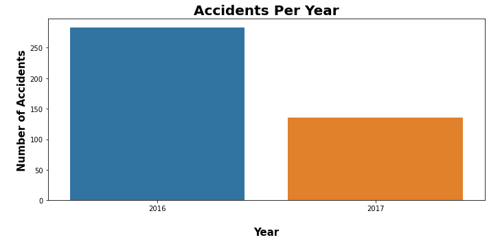

```python
# Displaying the total number of accidents per year
plt.figure(figsize=(10,5))
sns.countplot(x=data_raw['Date'].dt.year, data=data_raw)
plt.title("Accidents Per Year",fontsize=20,fontweight="bold")
plt.xlabel("\nYear", fontsize=15, fontweight="bold")
plt.ylabel("\nNumber of Accidents", fontsize=15, fontweight="bold")
plt.tight_layout()
```

There is data for 2 years, i.e, 2016 and 2017. However, it can be seen that there are lesser number of accidents reported in the year 2017. This could be because the data is not present for the entire year of 2017.

```python
# Displaying the months for which data is present in the year 2017
data_raw[(data_raw.Date >= '2017-01-01') & (data_raw.Date <= '2017-12-31')]['Date'].dt.month.unique()
```

```
array([1, 2, 3, 4, 5, 6, 7], dtype=int64)
```

As can be seen, for the year 2017, we have data only till the month of July

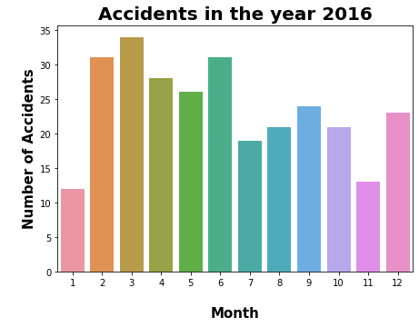

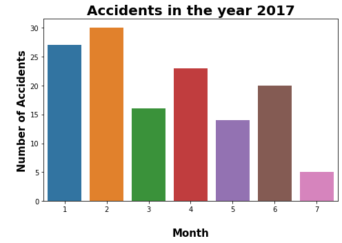

```python
# Displaying the number of accidents per month in the year of 2016 and 2017 for a comparative study
plt.figure(figsize=(7,5))
sns.countplot(x=data_raw[(data_raw.Date >= '2016-01-01') & (data_raw.Date <= '2016-12-31')]['Date'].dt.month, data=data_raw)
plt.title("Accidents in the year 2016", fontsize=20, fontweight="bold")
plt.xlabel("\nMonth", fontsize=15, fontweight="bold")
plt.ylabel("\nNumber of Accidents", fontsize=15, fontweight="bold")

plt.figure(figsize=(7,5))
sns.countplot(x=data_raw[(data_raw.Date >= '2017-01-01') & (data_raw.Date <= '2017-12-31')]['Date'].dt.month, data=data_raw)
plt.title("Accidents in the year 2017", fontsize=20, fontweight="bold")
plt.xlabel("\nMonth", fontsize=15, fontweight="bold")
plt.ylabel("\nNumber of Accidents", fontsize=15, fontweight="bold")
plt.tight_layout()
```

From the above two plots, it can be seen that:</br>

a. In the month of January 2017, there were more accidents than in the month of January 2016</br> b. In the month of March 2017, there were lesser accidents than in the month of March 2016</br> c. In the month of May 2017, there were lesser accidents than in the month of May 2016</br> d. In the month of June 2017, there were lesser accidents than in the month of June 2016</br> e. In the month of July 2017, there were lesser accidents than in the month of July 2016</br>

This decline in the number of accidents in the year 2017 can be further investigated to understand what preventive measures were taken by the companies.

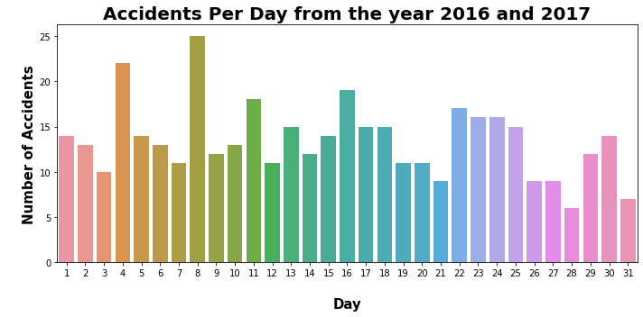

```python
# Displaying the number of accidents per day
plt.figure(figsize=(10,5))
sns.countplot(x=data_raw['Date'].dt.day, data=data_raw)
plt.title("Accidents Per Day from the year 2016 and 2017",fontsize=20,fontweight="bold")
plt.xlabel("\nDay", fontsize=15, fontweight="bold")
plt.ylabel("\nNumber of Accidents", fontsize=15, fontweight="bold")
plt.tight_layout()
```

### Analysing the Country Attribute

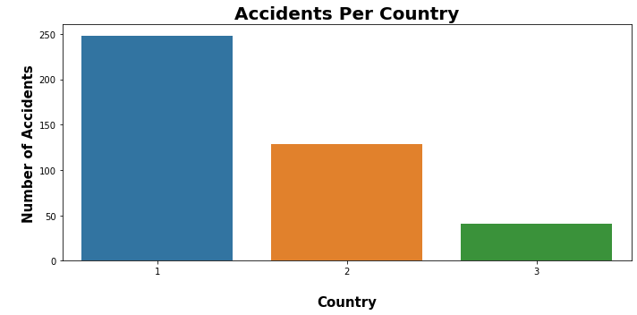

```python
# Displaying the number of accidents per country
plt.figure(figsize=(10,5))
sns.countplot(x=data_raw['Country'], order=data_raw['Country'].value_counts().index)
plt.title("Accidents Per Country",fontsize=20,fontweight="bold")
plt.xlabel("\nCountry", fontsize=15, fontweight="bold")
plt.ylabel("\nNumber of Accidents", fontsize=15, fontweight="bold")
plt.tight_layout()
```

Looks like maximum accidents have happened in Country_01

```python
# Displaying the actual number of accidents per country
data_raw['Country'].reset_index().groupby('Country').count()
```

| Country | index |
| --- | --- |
| 1 | 248 |
| 2 | 129 |
| 3 | 41 |

### Analysing the City attribute

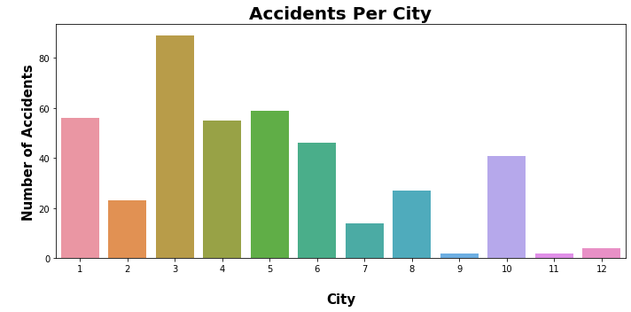

```python
# Displaying the number of accidents per city
plt.figure(figsize=(10,5))
sns.countplot(x=data_raw['City'])
plt.title("Accidents Per City",fontsize=20,fontweight="bold")
plt.xlabel("\nCity", fontsize=15, fontweight="bold")
plt.ylabel("\nNumber of Accidents", fontsize=15, fontweight="bold")
plt.tight_layout()
```

```python
# Displaying the actual number of accidents per city
data_raw['City'].reset_index().groupby('City').count()
```

| City | index |
| --- | --- |
| 1 | 56 |
| 2 | 23 |
| 3 | 89 |
| 4 | 55 |
| 5 | 59 |
| 6 | 46 |
| 7 | 14 |
| 8 | 27 |
| 9 | 2 |
| 10 | 41 |
| 11 | 2 |
| 12 | 4 |

Maximum accidents have been recorded for Local_03 which accounts for 21.29% of total accidents, followed by Local_05 and Local_01 accounting for 14.11% and 13.40% of the total accidents.

### Analysing the Industry Sector attribute

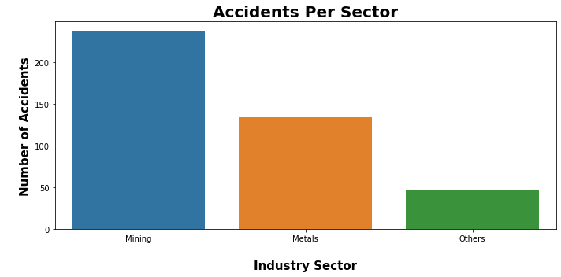

```python
# Displaying the number of accidents per sector
plt.figure(figsize=(10,5))
sns.countplot(x=data_raw['Industry Sector'])
plt.title("Accidents Per Sector",fontsize=20,fontweight="bold")
plt.xlabel("\nIndustry Sector", fontsize=15, fontweight="bold")
plt.ylabel("\nNumber of Accidents", fontsize=15, fontweight="bold")
plt.tight_layout()
```

From the plot, it can be seen that:</br>

a. 56.71% of accidents occur in Mining sector</br> b. 32.06% of accidents occured in Metals sector</br> c. 11.24% of accidents occured in other sectors</br>

### Analysing the Accident Level and Potential Accident Level attributes

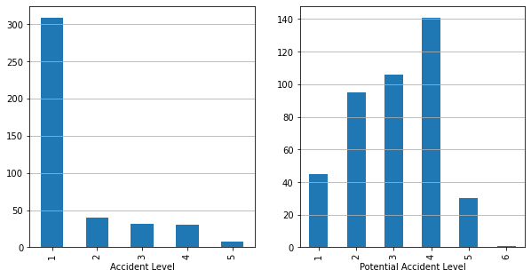

```python
# Displaying the number of accidents per Accident Level and Potential Accident Level
fig,ax = plt.subplots(nrows=1,ncols=2,figsize=(10,5))
data_raw['Accident Level'].reset_index().groupby('Accident Level').count().plot(kind="bar", legend=False, ax=ax[0]).grid(axis='y')
data_raw['Potential Accident Level'].reset_index().groupby('Potential Accident Level').count().plot(kind="bar", legend=False, ax=ax[1]).grid(axis='y')
plt.show()
```

Accident Level 1 has occured most number of times.

The potential accident level, i.e the severity of accident that could have happened is maximum for accident level 4.

### Analysing the Gender attribute

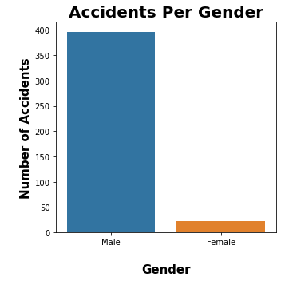

```python
plt.figure(figsize=(5,5))
sns.countplot(x=data_raw['Gender'])
plt.title("Accidents Per Gender",fontsize=20,fontweight="bold")
plt.xlabel("\nGender", fontsize=15, fontweight="bold")
plt.ylabel("\nNumber of Accidents", fontsize=15, fontweight="bold")
plt.tight_layout()
```

```python
# Displaying the actual number of accidents per gender
data_raw['Gender'].reset_index().groupby('Gender').count()
```

| Gender | index |
| --- | --- |
| Female | 22 |
| Male | 396 |

Most affected wokers in accidents are male .Their count is 396 ,which is equivalent to 94.74% of the total accidents in males and females.

### Analysing the Employee or Third Party attribute

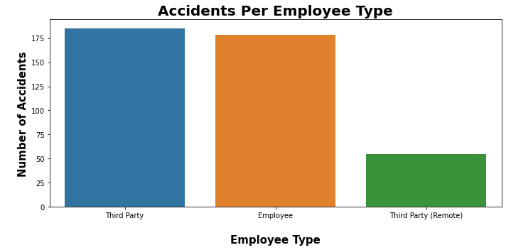

```python
plt.figure(figsize=(10,5))
sns.countplot(x=data_raw['Employee or Third Party'])
plt.title("Accidents Per Employee Type",fontsize=20,fontweight="bold")
plt.xlabel("\nEmployee Type", fontsize=15, fontweight="bold")
plt.ylabel("\nNumber of Accidents", fontsize=15, fontweight="bold")
plt.tight_layout()
```

```python
# Displaying the actual number of accidents per employee type
data_raw['Employee or Third Party'].reset_index().groupby('Employee or Third Party').count()
```

| Employee or Third Party | index |
| --- | --- |
| Employee | 178 |
| Third Party | 185 |
| Third Party (Remote) | 55 |

'Third Party' employee type is most prone to the risk of accidents

### Analysing the Critical Risk attribute

[output not shown]

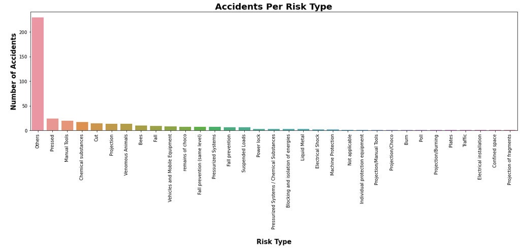

```python
# Displaying the number of accidents per risk type
plt.figure(figsize=(20,5))
descending_order = data_raw['Critical Risk'].value_counts().sort_values(ascending=False).index
sns.countplot(x=data_raw['Critical Risk'],order=descending_order);
plt.title("Accidents Per Risk Type",fontsize=20,fontweight="bold")
plt.xlabel("\nRisk Type", fontsize=15, fontweight="bold")
plt.ylabel("\nNumber of Accidents", fontsize=15, fontweight="bold")
plt.xticks(rotation = 'vertical')
```

```python
# Displaying the actual number of accidents per risk type
data_raw['Critical Risk'].reset_index().groupby('Critical Risk').count()
```

| Critical Risk | index |
| --- | --- |
| \nNot applicable | 1 |
| Bees | 10 |
| Blocking and isolation of energies | 3 |
| Burn | 1 |
| Chemical substances | 17 |
| Confined space | 1 |
| Cut | 14 |
| Electrical Shock | 2 |
| Electrical installation | 1 |
| Fall | 9 |
| Fall prevention | 6 |
| Fall prevention (same level) | 7 |
| Individual protection equipment | 1 |
| Liquid Metal | 3 |
| Machine Protection | 2 |
| Manual Tools | 20 |
| Others | 229 |
| Plates | 1 |
| Poll | 1 |
| Power lock | 3 |
| Pressed | 24 |
| Pressurized Systems | 7 |
| Pressurized Systems / Chemical Substances | 3 |
| Projection | 13 |
| Projection of fragments | 1 |
| Projection/Burning | 1 |
| Projection/Choco | 1 |
| Projection/Manual Tools | 1 |
| Suspended Loads | 6 |
| Traffic | 1 |
| Vehicles and Mobile Equipment | 8 |
| Venomous Animals | 13 |
| remains of choco | 7 |

There are a total of 33 critical risks covered in the dataset, out of which maximum risks are present under "others" category and post that comes "pressed" category of risk.

## b. Bivariate Analysis

### Analysing the Industry Sector attribute with Accident Level and Potential Accident Level attributes

```
(array([0, 1, 2]),
 [Text(0, 0, 'Mining'), Text(1, 0, 'Metals'), Text(2, 0, 'Others')])
```

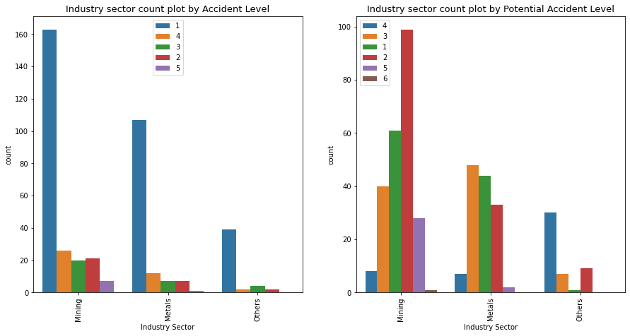

```python
# Displaying the plot
fig = plt.figure(figsize=(15, 7.2))
ax = fig.add_subplot(121)
sns.countplot(x='Industry Sector', data=data_raw, ax=ax, orient='v', hue='Accident Level').set_title('Industry sector count plot by Accident Level', fontsize = 13)
plt.legend(labels = data_raw['Accident Level'].unique())
plt.xticks(rotation = 90)
ax = fig.add_subplot(122)
sns.countplot(x='Industry Sector', data=data_raw, ax=ax, orient='v', hue='Potential Accident Level').set_title('Industry sector count plot by Potential Accident Level', fontsize = 13)
plt.legend(labels = data_raw['Potential Accident Level'].unique())
plt.xticks(rotation = 90)
```

From the Accident Level plot it can be seen that:</br>

a. Accident level I is highest in all industry sector (Mining, Metals and Other)</br> b. Most accidents happened in Mining industry sector</br> c. "Others" industry sector has less accidents in comparision to other industries</br> d. There are very few cases for Accident level 5. "Others" sector didn't reported any case for this level</br>

### Analysing the Country attirbute with Accident Level and Potential Accident Level attributes

```
(array([0, 1, 2]), [Text(0, 0, '1'), Text(1, 0, '2'), Text(2, 0, '3')])
```

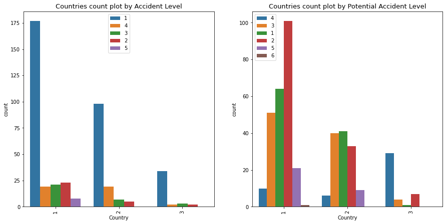

```python
# Displaying the plot
fig = plt.figure(figsize=(15, 7.2))
ax = fig.add_subplot(121)
sns.countplot(x='Country', data=data_raw, ax=ax, orient='v', hue='Accident Level').set_title('Countries count plot by Accident Level', fontsize=13)
plt.legend(labels = data_raw['Accident Level'].unique())
plt.xticks(rotation = 90)
ax = fig.add_subplot(122)
sns.countplot(x ='Country' , data=data_raw, ax=ax, orient='v', hue='Potential Accident Level').set_title('Countries count plot by Potential Accident Level', fontsize=13)
plt.legend(labels = data_raw['Potential Accident Level'].unique())
plt.xticks(rotation = 90)
```

From the Accident Level plot it can be seen that:</br>

a. Accident level I is highest in all countries</br> b. Most accidents happened in country 1</br> c. Accident level in country 3 is lesser than other countries</br>

From the Potential Accident Level plot it can be seen that</br>

a. Potential Accident level 4 is highest in Country 1</br> b. Most accidents happened in country 1</br> c. Accident level in country 3 is lesser than other countries

### Analysing the Date attribute with Accident Level and Potential Accident Level attributes

```
(array([0, 1]), [Text(0, 0, '2016'), Text(1, 0, '2017')])
```

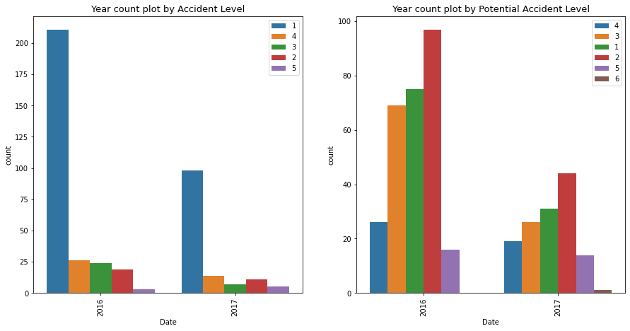

```python
# Displaying the plot
fig = plt.figure(figsize=(15, 7.2))
ax = fig.add_subplot(121)
sns.countplot(x=data_raw['Date'].dt.year, data=data_raw, ax=ax, orient='v', hue='Accident Level').set_title('Year count plot by Accident Level', fontsize = 13)
plt.legend(labels = data_raw['Accident Level'].unique())
plt.xticks(rotation = 90)
ax = fig.add_subplot(122)
sns.countplot(x=data_raw['Date'].dt.year, data=data_raw, ax=ax, orient='v', hue='Potential Accident Level').set_title('Year count plot by Potential Accident Level', fontsize = 13)
plt.legend(labels = data_raw['Potential Accident Level'].unique())
plt.xticks(rotation = 90)
```

From the Accident Level plot it can be seen that:</br>

a. Accident level I is highest in year 2016 and 2017</br> b. In Year 2016 more accidents happened in than 2017</br>

From the Potential Accident Level plot it can be seen that:</br>

a. Potential Accident level 4 is highest in year 2016 and 2017</br> b. In Year 2016 more potential accidents happened in than 2017</br> c. Potential Accident level 6 didn't happen in year 2016

### Analysing the City attribute with Accident Level and Potential Accident Level attributes

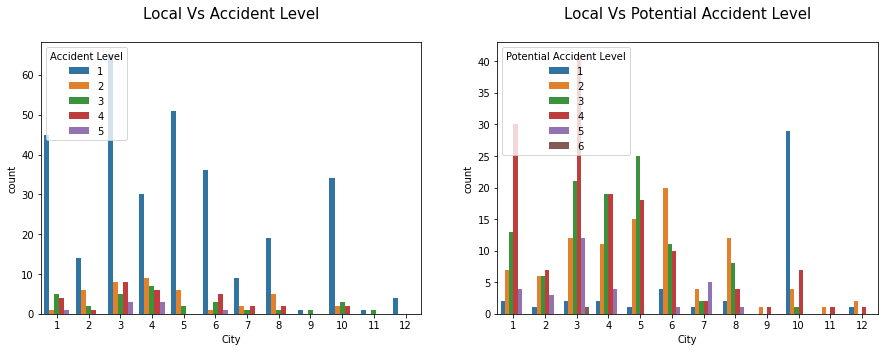

```python
# Displaying the plot
ig, (ax1,ax2) = plt.subplots(nrows=1, ncols=2, figsize=(15,5))
sns.countplot(x=data_raw['City'], hue=data_raw['Accident Level'], ax=ax1)
ax1.set_title('Local Vs Accident Level\n',fontsize=15)
sns.countplot(x=data_raw['City'], hue=data_raw['Potential Accident Level'], ax=ax2)
ax2.set_title('Local Vs Potential Accident Level\n', fontsize=15)
plt.show()
```

From the Accident Level plot it can be seen that:</br>

a. Accident level I is highest in almost all cities</br> b. Accident level I is highest in city 3</br> c. City 9,11 and 12 have less accidents level</br>

From the Potential Accident Level plot it can be seen that:</br>

a. Potential Accident level 4 is highest in City 3</br> b. Potential Accident level 4 is higher in most cities</br> c. City 9,11 and 12 have less potential accidents level</br> d. Potential Accident level 1 is highest in city 10</br> e. Potential Accident level 3 is highest in city 5

### Analysing the City attribute with the Date attribute

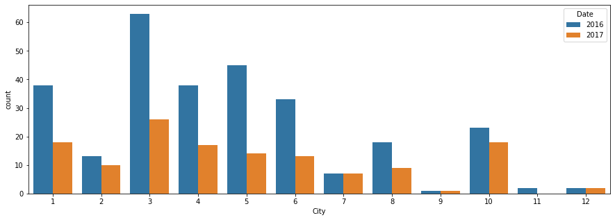

```python
# Displaying the plot
plt.figure(figsize=(15,5))
sns.countplot(x=data_raw["City"], hue=data_raw['Date'].dt.year);
```

From the above plot it can be seen that:</br>

a. In 2016 and 2017 local 3 has more accidents than other cities</br> b. City 9,11,12 has less accidents in 2016 and 2017 than all other cities

### Analysing the Country attribute with Date attribute

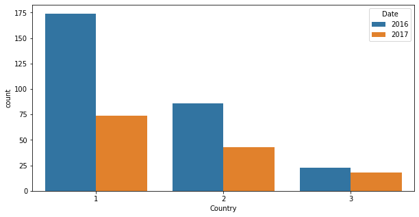

```python
# Displaying the plot
plt.figure(figsize=(10,5))
sns.countplot(x=data_raw["Country"], hue=data_raw['Date'].dt.year);
```

From the above plot it can be seen that:</br>

a. In 2016 and 2017 country 1 has more accidents than other countries</br> b. In 2016 and 2017 country 3 has least accidents than other countries

### Analysing the Country attribute with Employee Type attribute

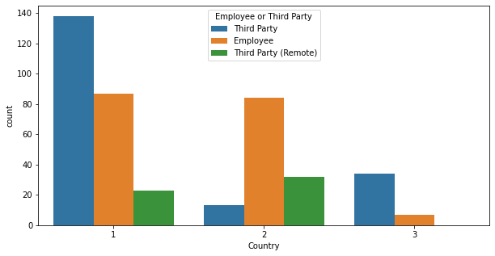

```python
# Displaying the plot
plt.figure(figsize=(10,5))
sns.countplot(x='Country', data=data_raw, hue='Employee or Third Party');
```

From the above plot it can be seen that:</br>

a. Incidents in Country 1 has Employee type of Third Party high in number</br> b. Incidents in Country 2 has Employee type of Employee high in number</br> c. Incidents in Country 3 has Employee type of Third Party high in number

### Analysing the Country attribute with Industry Sector attribute

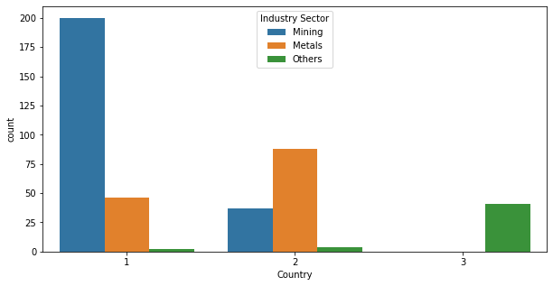

```python
plt.figure(figsize=(10,5))
sns.countplot(x='Country', data=data_raw, hue='Industry Sector');
```

From the above plot it can be seen that:</br> a. In Country 1, Incidents in Mining sector are very high</br> b. In Country 2, Incidents in Metals sector are very high</br> c. In Country 3, Incidents in Other sectors are very high

### Analysing the City attribute with Employee Type attribute

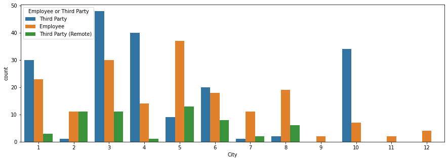

```python
# Displaying the plot
plt.figure(figsize=(15,5))
sns.countplot(x=data_raw['City'], hue=data_raw['Employee or Third Party']);
```

### Analysing the City attribute with Industry Sector attribute

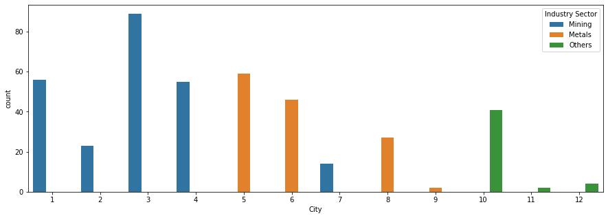

```python
# Displaying the plot
plt.figure(figsize=(15,5))
sns.countplot(x=data_raw['City'], hue=data_raw['Industry Sector']);
```

From the above plot it can be seen that:</br>

a. City 3 has highest number of Mining industry sector</br> b. City 5 has highest number of Metals industry sector</br> c. City 1,2,3,4,7 has Mining industry sector</br> d. City 5,6,8,9 has Metals industry sector</br> e. City 10,11,12 has Others industry sector

### Analysing the City attribute with Country attribute

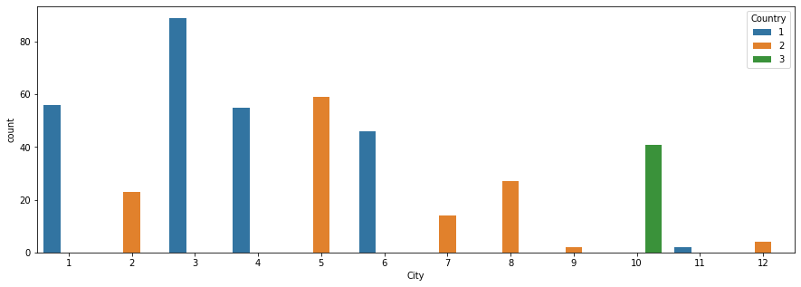

```python
# Displaying the plot
plt.figure(figsize=(15,5))
sns.countplot(x=data_raw['City'], hue=data_raw['Country']);
```

## 4. NLP Pre-processing

```python
# Defining a function to lemmatize the text
stop = set(stopwords.words('english'))

def preprocess_text(text):
    corpus=[]
    lem=WordNetLemmatizer()
    for news in text:
        words=[w for w in word_tokenize(news) if (w not in stop)]
        words=[lem.lemmatize(w) for w in words if len(w)>2]
        words = [''.join(c for c in s if c not in string.punctuation) for s in words if s]
        words = [word.lower() for word in words]
        words = [word for word in words if word.isalpha()]
        corpus.append(words)
    return corpus
```

```python
# Creating a new attribute with the lemmatized text
data_raw['Processed_Description'] = preprocess_text(data_raw['Description'])
```

```python
# Displaying the maximum length of processed words
word_lengths = []
for i in data_raw['Processed_Description']:
    word_lengths.append(len(i))
print('Maximum length of the words in processed text (in list) :', max(word_lengths))
```

```
Maximum length of the words in processed text (in list) : 95
```

```python
# Concatenating the list of lemmatized words
concatenatedDescription = []
for i in range(len(data_raw['Processed_Description'])):
    concatenatedDescription.append(' '.join(wrd for wrd in data_raw.iloc[:,10][i]))
data_raw['Processed_Description'] = concatenatedDescription
```

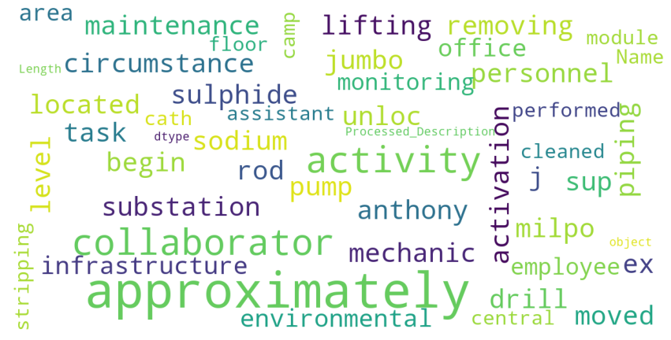

```python
# Generating the wordcloud for the Processed Description
wordcloud = WordCloud(
        background_color='white',
        stopwords=set(STOPWORDS),
        max_words=100,
        max_font_size=30,
        scale=3,
        random_state=1)

wordcloud = wordcloud.generate(str(data_raw['Processed_Description']))

fig = plt.figure(1, figsize=(15, 15))
plt.axis('off')
plt.imshow(wordcloud)
plt.show()
```

```python
# Displaying the head of the data after all the NLP processing has been done
data_raw.head(3)
```

|  | Date | Country | City | Industry Sector | Accident Level | Potential Accident Level | Gender | Employee or Third Party | Critical Risk | Description | Processed_Description |
| --- | --- | --- | --- | --- | --- | --- | --- | --- | --- | --- | --- |
| 0 | 2016-01-01 | 1 | 1 | Mining | 1 | 4 | Male | Third Party | Pressed | While removing the drill rod of the Jumbo 08 f... | while removing drill rod jumbo maintenance sup... |
| 1 | 2016-01-02 | 2 | 2 | Mining | 1 | 4 | Male | Employee | Pressurized Systems | During the activation of a sodium sulphide pum... | during activation sodium sulphide pump piping ... |
| 2 | 2016-01-06 | 1 | 3 | Mining | 1 | 3 | Male | Third Party (Remote) | Manual Tools | In the sub-station MILPO located at level +170... | substation milpo located level collaborator ex... |

```python
# Defining the predictor and target attributes
X = data_raw['Processed_Description']
y = data_raw['Accident Level']
yp = data_raw['Potential Accident Level']
```

## 5. Model training and testing using Count Vectorizer

### Considering 'Accident Level' as the target attribute

```python
# Creating an instance of the Count Vectorizer
count_vectorizer = CountVectorizer(analyzer='word', ngram_range=(1, 3))
Xc = count_vectorizer.fit_transform(X).toarray()
Xc_train, Xc_test, yc_train, yc_test = train_test_split(Xc, y, test_size=0.15, random_state=42)
```

### a. SVC model training and evaluation

```python
# Creating an instace of the SVC model and training it
svc1 = LinearSVC(max_iter=2500, C=1.0)
svc1.fit(Xc_train, yc_train)
y_predicted1 = svc1.predict(Xc_test)
```

```python
# Displaying the accuracy of the SVC model on the training and testing data
print("Train accuracy of the SVC model : {:.2f}".format(svc1.score(Xc_train, yc_train) * 100))
print("Test accuracy of the SVC model : {:.2f}".format(accuracy_score(yc_test, y_predicted1) * 100))
acc_svc1 = accuracy_score(yc_test, y_predicted1)
```

```
Train accuracy of the SVC model : 99.44
Test accuracy of the SVC model : 76.19
```

### b. Random Forest model training and evaluation

```python
# Creating an instance of the Random Forest Model and training it
rfc1 = RandomForestClassifier(random_state=42, max_leaf_nodes=10)
rfc1.fit(Xc_train, yc_train)
y_predicted2 = rfc1.predict(Xc_test)
```

```python
# Displaying the accuracy of the Random Forest model on training and testing data
print("Train Accuracy of the Random Forest model : {:.2f}".format(rfc1.score(Xc_train,yc_train) * 100))
print("Test Accuracy of the Random Forest model : {:.2f}".format(accuracy_score(yc_test, y_predicted2) * 100))
acc_rfc1 = accuracy_score(yc_test, y_predicted2)
```

```
Train Accuracy of the Random Forest model : 73.52
Test Accuracy of the Random Forest model : 76.19
```

### c. Gradient Boosting model training and evaluation

```python
# Creating an instance of the Gradient Boosting model and training it
gbc1 = GradientBoostingClassifier(n_estimators=100, min_samples_split=2)
gbc1.fit(Xc_train, yc_train)
y_predicted3 = gbc1.predict(Xc_test)
```

```python
# Displaying the accuracy of the Gradient Boosting model on training and testing data
print("Train accuracy of the Gradient boosting model : {:.2f}".format(gbc1.score(Xc_train,yc_train) * 100))
print("Test accuracy of the Gradient boosting model : {:.2f}".format(accuracy_score(yc_test, y_predicted3) * 100))
acc_gbc1 = accuracy_score(yc_test, y_predicted3)
```

```
Train accuracy of the Gradient boosting model : 99.44
Test accuracy of the Gradient boosting model : 73.02
```

### d. XGBoost Model training and evaluation

```python
# Creating an instance of the XGBoost model and training it
xgbc1 = XGBClassifier()
xgbc1.fit(Xc_train, yc_train)
y_predicted4 = xgbc1.predict(Xc_test)
```

```
[14:29:22] WARNING: C:/Users/Administrator/workspace/xgboost-win64_release_1.4.0/src/learner.cc:1095: Starting in XGBoost 1.3.0, the default evaluation metric used with the objective 'multi:softprob' was changed from 'merror' to 'mlogloss'. Explicitly set eval_metric if you'd like to restore the old…
```

```python
# Displaying the accuracy of the XGBoost model on the training and testing data
print("Train accuracy of the XGBoost model : {:.2f}".format(xgbc1.score(Xc_train,yc_train) * 100))
print("Test accuracy of the XGBoost model : {:.2f}".format(accuracy_score(yc_test, y_predicted4) * 100))
acc_xgb1 = accuracy_score(yc_test, y_predicted4)
```

```
Train accuracy of the XGBoost model : 99.44
Test accuracy of the XGBoost model : 66.67
```

### e. Neural Network model traing and evaluation

```python
# Defining and training a Neural Network
seed = 7
np.random.seed(seed)
tf.random.set_seed(seed)

# define the Neural Network
model1 = Sequential()
model1.add(Dense(50, input_dim=Xc_train.shape[1], activation='relu', kernel_initializer='he_uniform'))
model1.add(Dense(100, activation='relu', kernel_initializer='he_uniform'))
model1.add(Dense(150, activation='relu', kernel_initializer='he_uniform'))
model1.add(Dense(40, activation='relu', kernel_initializer='he_uniform'))
model1.add(Dense(1, activation='linear'))

# compile the keras model
opt = SGD(lr=0.001, momentum=0.9)
model1.compile(loss='mse', optimizer=opt, metrics=['accuracy'])

# Use earlystopping
callback = tf.keras.callbacks.EarlyStopping(monitor='loss', patience=5, min_delta=0.001)
rlrp = ReduceLROnPlateau(monitor='val_loss', factor=0.0001, patience=5, min_delta=1E-4)

# Training the Neural Network model on the dataset
training_history1 = model1.fit(Xc_train, yc_train, epochs=10, batch_size=8, verbose=1, validation_data=(Xc_test, yc_test), callbacks=[rlrp])
```

```python
# Displaying the accuracy of the Neural Network model on the training and testing data
_, acc_tr_nn1 = model1.evaluate(Xc_train, yc_train, batch_size=8, verbose=0)
_, acc_te_nn1 = model1.evaluate(Xc_test, yc_test, batch_size=8, verbose=0)

print('Train accuracy: %.2f' % (acc_tr_nn1 * 100))
print('Test accuracy: %.2f' % (acc_te_nn1 * 100))
```

```
Train accuracy: 73.52
Test accuracy: 76.19
```

### Considering Potential Accident level as the target attribute

```python
# Creating an instance of the Count Vectorizer
count_vectorizer = CountVectorizer(analyzer='word', ngram_range=(1, 3))
Xp = count_vectorizer.fit_transform(X).toarray()
Xp_train, Xp_test, yp_train, yp_test = train_test_split(Xp, yp, test_size=0.15, random_state=42)
yp_train = yp_train.astype('int')
```

### a. SVC Model training and evaluation

```python
# Creating an instance of the SVC model and training it
svc2 = LinearSVC(max_iter=5500)
svc2.fit(Xp_train, yp_train)
y_predicted1 = svc2.predict(Xp_test)
```

```python
# Displaying the accuracy of the SVC model on the training and testing data
print("Train accuracy of the SVC model : {:.2f}".format(svc2.score(Xp_train,yp_train) * 100))
print("Test accuracy of the SVC model : {:.2f}".format(accuracy_score(yp_test, y_predicted1) * 100))
acc_svc2 = accuracy_score(yp_test, y_predicted1)
```

```
Train accuracy of the SVC model : 99.72
Test accuracy of the SVC model : 44.44
```

### b. Random Forest model training and evaluation

```python
# Creating and instance of the RandomForest model and training it
rfc2 = RandomForestClassifier(random_state=42)
rfc2.fit(Xp_train, yp_train)
y_predicted2 = rfc2.predict(Xp_test)
```

```python
# Displaying the accuracy of the Random Forest model on the training and testing data
print("Train accuracy of the Random Forest model : {:.2f}".format(rfc2.score(Xp_train,yp_train) * 100))
print("Test accuracy of the Random Forest model : {:.2f}".format(accuracy_score(yp_test, y_predicted2) * 100))
acc_rfc2 = accuracy_score(yp_test, y_predicted2)
```

```
Train accuracy of the Random Forest model : 99.72
Test accuracy of the Random Forest model : 34.92
```

```python
# Creating an instance of the XGBoosting model and training it
xgb2 = XGBClassifier()
xgb2.fit(Xp_train, yp_train)
y_predicted3 = xgb2.predict(Xp_test)
```

```
[14:29:54] WARNING: C:/Users/Administrator/workspace/xgboost-win64_release_1.4.0/src/learner.cc:1095: Starting in XGBoost 1.3.0, the default evaluation metric used with the objective 'multi:softprob' was changed from 'merror' to 'mlogloss'. Explicitly set eval_metric if you'd like to restore the old…
```

```python
# Displaying the accuracy of the XGBoost model on the training and testing data
print("Train accuracy of the XGBoost model : {:.2f}".format(xgb2.score(Xp_train,yp_train) * 100))
print("Test accuracy of the XGBoost model : {:.2f}".format(accuracy_score(yp_test, y_predicted3) * 100))
acc_xgb2 = accuracy_score(yp_test, y_predicted3)
```

```
Train accuracy of the XGBoost model : 99.72
Test accuracy of the XGBoost model : 38.10
```

### d. Neural Network model training and evaluation

```python
# Defining and training a Neural Network
seed = 7
np.random.seed(seed)
tf.random.set_seed(seed)

# define the Neural Network
model2 = Sequential()
model2.add(Dense(50, input_dim=Xp_train.shape[1], activation='relu', kernel_initializer='he_uniform'))
model2.add(Dense(100, activation='relu', kernel_initializer='he_uniform'))
model2.add(Dense(150, activation='relu', kernel_initializer='he_uniform'))
model2.add(Dense(40, activation='relu', kernel_initializer='he_uniform'))
model2.add(Dense(1, activation='linear'))

# compile the keras model
opt = SGD(lr=0.001, momentum=0.9)
model2.compile(loss='mse', optimizer=opt, metrics=['accuracy'])

# Use earlystopping
callback = tf.keras.callbacks.EarlyStopping(monitor='loss', patience=5, min_delta=0.001)
rlrp = ReduceLROnPlateau(monitor='val_loss', factor=0.0001, patience=5, min_delta=1E-4)

# Training the Neural Network model on the dataset
training_history2 = model2.fit(Xp_train, yp_train, epochs=10, batch_size=8, verbose=1, validation_data=(Xp_test, yp_test), callbacks=[rlrp])
```

```python
# Evaluate the Neural Network model
_, acc_tr_nn2 = model2.evaluate(Xp_train, yp_train, batch_size=8, verbose=0)
_, acc_te_nn2 = model2.evaluate(Xp_test, yp_test, batch_size=8, verbose=0)

print('Train accuracy: %.2f' % (acc_tr_nn2 * 100))
print('Test accuracy: %.2f' % (acc_te_nn2 * 100))
```

```
Train accuracy: 10.70
Test accuracy: 11.11
```

## 6. Model training, testing and tuning using TF-IDF

### Considering 'Accident level' as the target attribute

```python
# Creating an instance of the TFIDF Vectorizer
tfidf_vec = TfidfVectorizer(ngram_range=(1,3))
Xt = tfidf_vec.fit_transform(X).toarray()
Xt_train, Xt_test, yt_train, yt_test = train_test_split(Xt, y, test_size=0.15, random_state=42)
```

### a. SVC Model training and evaluation

```python
# Creating an instance of the SVC Model
svc3= LinearSVC(max_iter=5500)
svc3.fit(Xt_train, yt_train)
y_predicted1 = svc3.predict(Xt_test)
```

```python
# Displaying the accuracy of the SVC model on the training and testing data
print("Train accuracy of the SVC model : {:.2f}".format(svc3.score(Xt_train,yt_train) * 100))
print("Test accuracy of the SVC model : {:.2f}".format(accuracy_score(yt_test, y_predicted1) * 100))
acc_svc3 = accuracy_score(yt_test, y_predicted1)
```

```
Train accuracy of the SVC model : 99.15
Test accuracy of the SVC model : 76.19
```

### b. Gradient Boosting Model training and evaluation

```python
# Creating an instance of the GradientBoostingClassifier and training it
gbc3 = GradientBoostingClassifier(n_estimators=100)
gbc3.fit(Xt_train, yt_train)
y_predicted2 = gbc3.predict(Xt_test)
```

```python
# Displaying the accuracy of the GradientBoosting model on training and testing data
print("Train accuracy of the Gradient boosting model : {:.2f}".format(gbc3.score(Xt_train,yt_train) * 100))
print("Test accuracy of the Gradient boosting model : {:.2f}".format(accuracy_score(yt_test, y_predicted1) * 100))
acc_gbc3 = accuracy_score(yt_test, y_predicted2)
```

```
Train accuracy of the Gradient boosting model : 99.44
Test accuracy of the Gradient boosting model : 76.19
```

### c. Random Forest model training and evaluation

```python
# Creating an instance of the RandomForest model and training it
rfc3 = RandomForestClassifier(random_state=42)
rfc3.fit(Xt_train, yt_train)
y_predicted3 = rfc3.predict(Xt_test)
```

```python
# Displaying the accuracy of the Random Forest model on the training and testing data
print("Train accuracy of the Random Forest model : {:.2f}".format(rfc3.score(Xt_train,yt_train) * 100))
print("Test accuracy of the Random Forest model : {:.2f}".format(accuracy_score(yt_test, y_predicted3) * 100))
acc_rfc3 = accuracy_score(yt_test, y_predicted3)
```

```
Train accuracy of the Random Forest model : 99.44
Test accuracy of the Random Forest model : 76.19
```

### d. XGBoost model for training and evaluation

```python
# Creating an instance of the XGBoost model and training it
xgbc3 = XGBClassifier()
xgbc3.fit(Xt_train, yt_train)
y_predicted4 = xgbc3.predict(Xt_test)
```

```
[14:33:54] WARNING: C:/Users/Administrator/workspace/xgboost-win64_release_1.4.0/src/learner.cc:1095: Starting in XGBoost 1.3.0, the default evaluation metric used with the objective 'multi:softprob' was changed from 'merror' to 'mlogloss'. Explicitly set eval_metric if you'd like to restore the old…
```

```python
print("Train accuracy of the XGBoost model : {:.2f}".format(xgbc3.score(Xt_train,yt_train) * 100))
print("Test accuracy of the XGBoost model : {:.2f}".format(accuracy_score(yt_test, y_predicted4) * 100))
acc_xgb3 = accuracy_score(yt_test, y_predicted4)
```

```
Train accuracy of the XGBoost model : 99.44
Test accuracy of the XGBoost model : 71.43
```

### e. Neural Network training and evaluation

```python
# Defining and training a Neural Network
seed = 7
np.random.seed(seed)
tf.random.set_seed(seed)

# define the Neural Network
model3 = Sequential()
model3.add(Dense(50, input_dim=Xt_train.shape[1], activation='relu', kernel_initializer='he_uniform'))
model3.add(Dense(100, activation='relu', kernel_initializer='he_uniform'))
model3.add(Dense(150, activation='relu', kernel_initializer='he_uniform'))
model3.add(Dense(40, activation='relu', kernel_initializer='he_uniform'))
model3.add(Dense(1, activation='linear'))

# compile the keras model
opt = SGD(lr=0.001, momentum=0.9)
model3.compile(loss='mse', optimizer=opt, metrics=['accuracy'])

# Use earlystopping
callback = tf.keras.callbacks.EarlyStopping(monitor='loss', patience=5, min_delta=0.001)
rlrp = ReduceLROnPlateau(monitor='val_loss', factor=0.0001, patience=5, min_delta=1E-4)

# Training the Neural Network model on the dataset
training_history3 = model3.fit(Xt_train, yt_train, epochs=10, batch_size=8, verbose=1, validation_data=(Xt_test, yt_test), callbacks=[rlrp])
```

```python
# Evaluate the Neural Network model
_, acc_tr_nn3 = model3.evaluate(Xt_train, yt_train, batch_size=8, verbose=0)
_, acc_te_nn3 = model3.evaluate(Xt_test, yt_test, batch_size=8, verbose=0)

print('Train accuracy: %.2f' % (acc_tr_nn3 * 100))
print('Test accuracy: %.2f' % (acc_te_nn3 * 100))
```

```
Train accuracy: 73.52
Test accuracy: 76.19
```

### Considering Potential Accident level as the target attribute

```python
# Creating an instance of the TF-IDF vectorizer with Potential Accident Level as the target attribute
tfidf_vec = TfidfVectorizer(ngram_range=(1,3))
Xtp = tfidf_vec.fit_transform(X).toarray()

Xtp_train, Xtp_test, ytp_train, ytp_test = train_test_split(Xtp, yp, test_size=0.15, random_state=42)
```

### a. SVC model training and evaluation

```python
# Creating an instance of the SVC model and training it
svc4 = LinearSVC(max_iter=5500)
svc4.fit(Xtp_train, ytp_train)
y_predicted1 = svc4.predict(Xtp_test)
```

```python
# Displaying the accuracy of the SVC model on training and testing data
print("Train accuracy of the SVC model : {:.2f}".format(svc4.score(Xtp_train,ytp_train) * 100))
print("Test accuracy of the SVC model : {:.2f}".format(accuracy_score(ytp_test, y_predicted1) * 100))
acc_svc4 = accuracy_score(ytp_test, y_predicted1)
```

```
Train accuracy of the SVC model : 99.72
Test accuracy of the SVC model : 44.44
```

### b. Gradient Boosting model training and evaluation

```python
# Creating an instance of the GradientBoosting model and training it
gbc4 = GradientBoostingClassifier(n_estimators=100)
gbc4.fit(Xtp_train, ytp_train)
y_predicted2 = gbc4.predict(Xtp_test)
```

```python
# Displaying the accuracy of the GradientBoosting model on training and testing data
print("Train accuracy of the Gradient boosting model : {:.2f}".format(gbc4.score(Xtp_train, ytp_train) * 100))
print("Test accuracy of the Gradient boosting model : {:.2f}".format(accuracy_score(ytp_test, y_predicted2) * 100))
acc_gbc4 = accuracy_score(ytp_test, y_predicted2)
```

```
Train accuracy of the Gradient boosting model : 99.72
Test accuracy of the Gradient boosting model : 41.27
```

### c. Random Forest model training and evaluation

```python
# Creating an instance of the RandomForest model and training it
rfc4 = RandomForestClassifier(random_state=42)
rfc4.fit(Xtp_train, ytp_train)
y_predicted3 = rfc4.predict(Xtp_test)
```

```python
# Displaying the accuracy of the RandomForest model on the training and testing data
print("Train accuracy of the Random Forest model : {:.2f}".format(rfc4.score(Xtp_train, ytp_train) * 100))
print("Test accuracy of the Random Forest model : {:.2f}".format(accuracy_score(ytp_test, y_predicted3) * 100))
acc_rfc4 = accuracy_score(ytp_test, y_predicted3)
```

```
Train accuracy of the Random Forest model : 99.72
Test accuracy of the Random Forest model : 47.62
```

### d. XGBoost model for training and evaluation

```python
# Creating and instance of the XGBoosting model and training it
xgbc4 = XGBClassifier()
xgbc4.fit(Xtp_train, ytp_train)
y_predicted4 = xgbc4.predict(Xtp_test)
```

```
[14:38:50] WARNING: C:/Users/Administrator/workspace/xgboost-win64_release_1.4.0/src/learner.cc:1095: Starting in XGBoost 1.3.0, the default evaluation metric used with the objective 'multi:softprob' was changed from 'merror' to 'mlogloss'. Explicitly set eval_metric if you'd like to restore the old…
```

```python
# Displaying the accuracy of the XGBoosting model on the training and testing data
print("Train accuracy of the XGBoost model : {:.2f}".format(xgbc4.score(Xtp_train,ytp_train) * 100))
print("Test accuracy of the XGBoost model : {:.2f}".format(accuracy_score(ytp_test, y_predicted4) * 100))
acc_xgb4 = accuracy_score(ytp_test, y_predicted4)
```

```
Train accuracy of the XGBoost model : 99.72
Test accuracy of the XGBoost model : 44.44
```

### e. Neural Network model training and evaluation

```python
# Defining and training a Neural Network
seed = 7
np.random.seed(seed)
tf.random.set_seed(seed)

# define the Neural Network
model4 = Sequential()
model4.add(Dense(50, input_dim=Xtp_train.shape[1], activation='relu', kernel_initializer='he_uniform'))
model4.add(Dense(100, activation='relu', kernel_initializer='he_uniform'))
model4.add(Dense(150, activation='relu', kernel_initializer='he_uniform'))
model4.add(Dense(40, activation='relu', kernel_initializer='he_uniform'))
model4.add(Dense(1, activation='linear'))

# compile the keras model
opt = SGD(lr=0.001, momentum=0.9)
model4.compile(loss='mse', optimizer=opt, metrics=['accuracy'])

# Use earlystopping
callback = tf.keras.callbacks.EarlyStopping(monitor='loss', patience=5, min_delta=0.001)
rlrp = ReduceLROnPlateau(monitor='val_loss', factor=0.0001, patience=5, min_delta=1E-4)

# Training the Neural Network model on the dataset
training_history4 = model4.fit(Xtp_train, ytp_train, epochs=10, batch_size=8, verbose=1, validation_data=(Xtp_test, ytp_test), callbacks=[rlrp])
```

```python
# Evaluate the Neural Network model
_, acc_tr_nn4 = model4.evaluate(Xtp_train, ytp_train, batch_size=8, verbose=0)
_, acc_te_nn4 = model4.evaluate(Xtp_test, ytp_test, batch_size=8, verbose=0)

print('Train accuracy: %.2f' % (acc_tr_nn4 * 100))
print('Test accuracy: %.2f' % (acc_te_nn4 * 100))
```

```
Train accuracy: 10.70
Test accuracy: 11.11
```

### Considering Accident Level as the target attribute

```python
# Declaring the maximum number of features
max_features = 10000
maxlen = max(word_lengths)
embedding_size = 200
```

```python
# Toeknizing the data
tokenizer = Tokenizer(num_words = max_features)
tokenizer.fit_on_texts(list(data_raw['Processed_Description']))
```

```python
# Padding the data
Xw = tokenizer.texts_to_sequences(data_raw['Processed_Description'])
Xw = pad_sequences(Xw, maxlen = maxlen)
yw = y
```

```python
# Reserve padding (indexed zero)
w2i = tokenizer.word_index
vocab_size = len(w2i) + 1
```

```python
# Importing the Glove file
EMBEDDING_FILE = 'glove.6B.200d.txt'

embeddings = {}
for o in open(EMBEDDING_FILE,encoding='utf-8'):
    word = o.split(' ')[0]
    embd = o.split(' ')[1:]
    embd = np.asarray(embd, dtype = 'float32')
    embeddings[word] = embd
```

```python
num_words = min(max_features, vocab_size) + 1

embedding_matrix = np.zeros((num_words, embedding_size))
for word, i in tokenizer.word_index.items():
    if i > max_features: continue
    embedding_vector = embeddings.get(word)
    if embedding_vector is not None:
        embedding_matrix[i] = embedding_vector

len(embeddings.values())
```

```
400000
```

```python
# Creating the training and testing data
Xw_train, Xw_test, yw_train, yw_test = train_test_split(Xw, yw, test_size = 0.3, random_state = 42, shuffle = True)
```

```python
# Creating a LSTM Model and training it
model5 = Sequential()
model5.add(Embedding(num_words, embedding_size, embeddings_initializer = Constant(embedding_matrix), input_length = maxlen, trainable = False))
model5.add(Bidirectional(LSTM(128, return_sequences = True)))
model5.add(GlobalMaxPool1D())
model5.add(Dropout(0.5, input_shape = (256,)))
model5.add(Dense(128, activation = 'relu'))
model5.add(Dropout(0.5, input_shape = (128,)))
model5.add(Dense(64, activation = 'relu'))
model5.add(Dropout(0.5, input_shape = (64,)))
model5.add(Dense(6, activation = 'softmax'))
model5.compile(loss = 'sparse_categorical_crossentropy', optimizer = 'adam', metrics = ['accuracy'])

training_history5 = model5.fit(Xw_train, yw_train, epochs = 10, validation_split = 0.2, batch_size = 30, verbose = 2)
```

```
8/8 - 5s - loss: 1.4542 - accuracy: 0.4979 - val_loss: 0.9630 - val_accuracy: 0.7627 - 5s/epoch - 613ms/step
8/8 - 1s - loss: 1.2142 - accuracy: 0.7167 - val_loss: 0.9032 - val_accuracy: 0.7627 - 713ms/epoch - 89ms/step
8/8 - 1s - loss: 1.1455 - accuracy: 0.7253 - val_loss: 0.9550 - val_accuracy: 0.7627 - 717ms/epoch - 90ms/step
8/8 - 1s - loss: 1.0476 - accuracy: 0.7296 - val_loss: 0.9362 - val_accuracy: 0.7627 - 714ms/epoch - 89ms/step
8/8 - 1s - loss: 1.0854 - accuracy: 0.7167 - val_loss: 0.8994 - val_accuracy: 0.7627 - 781ms/epoch - 98ms/step
8/8 - 1s - loss: 1.0530 - accuracy: 0.7253 - val_loss: 0.8965 - val_accuracy: 0.7627 - 805ms/epoch - 101ms/step
8/8 - 1s - loss: 1.0793 - accuracy: 0.7296 - val_loss: 0.8922 - val_accuracy: 0.7627 - 825ms/epoch - 103ms/step
8/8 - 1s - loss: 0.9873 - accuracy: 0.7296 - val_loss: 0.8919 - val_accuracy: 0.7627 - 817ms/epoch - 102ms/step
8/8 - 1s - loss: 1.0036 - accuracy: 0.7382 - val_loss: 0.9026 - val_accuracy: 0.7627 - 795ms/epoch - 99ms/step
8/8 - 1s - loss: 0.9585 - accuracy: 0.7210 - val_loss: 0.8785 - val_accuracy: 0.7627 - 769ms/epoch - 96ms/step
```

```python
# Displaying the accuracy of the model with testing data
loss, accuracy = model5.evaluate(Xw_test, yw_test, verbose = 0)
print('Overall Accuracy: {}'.format(round(accuracy * 100, 0)))
```

```
Overall Accuracy: 75.0
```

### Considering Potential Accident Level as the target attribute

```python
# Creating the training and testing data
Xwp_train, Xwp_test, ywp_train, ywp_test = train_test_split(Xw, yp, test_size = 0.3, random_state = 42, shuffle = True)
```

```python
# Creaating an LSTM model and training it
model6 = Sequential()
model6.add(Embedding(num_words, embedding_size, embeddings_initializer = Constant(embedding_matrix), input_length = maxlen, trainable = False))
model6.add(Bidirectional(LSTM(128, return_sequences = True)))
model6.add(GlobalMaxPool1D())
model6.add(Dropout(0.5, input_shape = (256,)))
model6.add(Dense(128, activation = 'relu'))
model6.add(Dropout(0.5, input_shape = (128,)))
model6.add(Dense(64, activation = 'relu'))
model6.add(Dropout(0.5, input_shape = (64,)))
model6.add(Dense(7, activation = 'softmax'))

model6.compile(loss = 'sparse_categorical_crossentropy', optimizer = 'adam', metrics = ['accuracy'])
training_history6 = model6.fit(Xwp_train, ywp_train, epochs = 10, validation_split = 0.2, batch_size = 30, verbose = 2)
```

```
8/8 - 4s - loss: 1.8655 - accuracy: 0.1760 - val_loss: 1.6742 - val_accuracy: 0.3390 - 4s/epoch - 561ms/step
8/8 - 1s - loss: 1.7052 - accuracy: 0.3004 - val_loss: 1.6163 - val_accuracy: 0.3559 - 751ms/epoch - 94ms/step
8/8 - 1s - loss: 1.6527 - accuracy: 0.3348 - val_loss: 1.5960 - val_accuracy: 0.3729 - 727ms/epoch - 91ms/step
8/8 - 1s - loss: 1.6897 - accuracy: 0.2790 - val_loss: 1.5826 - val_accuracy: 0.3729 - 812ms/epoch - 101ms/step
8/8 - 1s - loss: 1.5947 - accuracy: 0.3605 - val_loss: 1.5688 - val_accuracy: 0.3729 - 964ms/epoch - 121ms/step
8/8 - 1s - loss: 1.5999 - accuracy: 0.3219 - val_loss: 1.5459 - val_accuracy: 0.3729 - 777ms/epoch - 97ms/step
8/8 - 1s - loss: 1.6236 - accuracy: 0.3176 - val_loss: 1.5861 - val_accuracy: 0.3729 - 821ms/epoch - 103ms/step
8/8 - 1s - loss: 1.5623 - accuracy: 0.2790 - val_loss: 1.5639 - val_accuracy: 0.3729 - 960ms/epoch - 120ms/step
8/8 - 1s - loss: 1.5023 - accuracy: 0.3305 - val_loss: 1.5333 - val_accuracy: 0.3390 - 755ms/epoch - 94ms/step
8/8 - 1s - loss: 1.5931 - accuracy: 0.2833 - val_loss: 1.5101 - val_accuracy: 0.3559 - 983ms/epoch - 123ms/step
```

```python
# Displaying the accuracy of the model with testing data
lossp, accuracyp = model6.evaluate(Xwp_test, ywp_test, verbose = 0)
print('Overall Accuracy: {}'.format(round(accuracyp * 100, 0)))
```

```
Overall Accuracy: 32.0
```

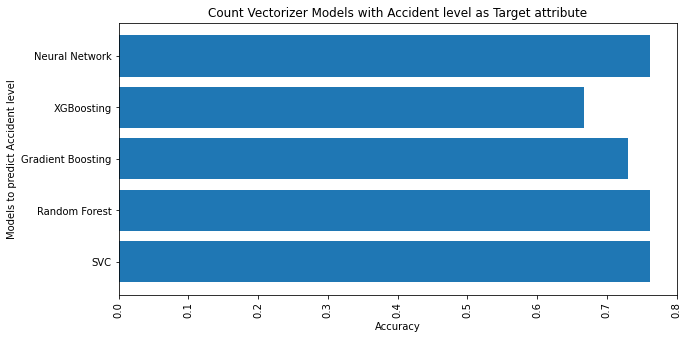

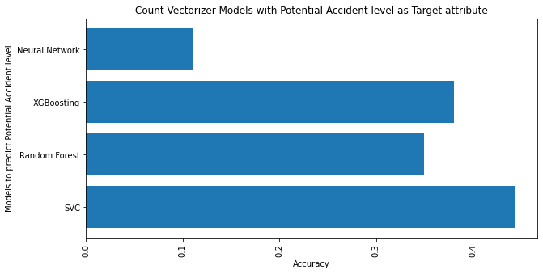

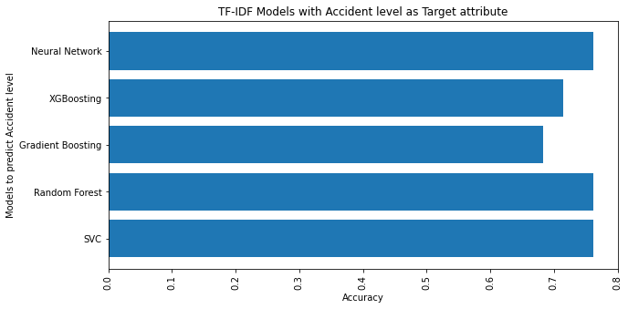

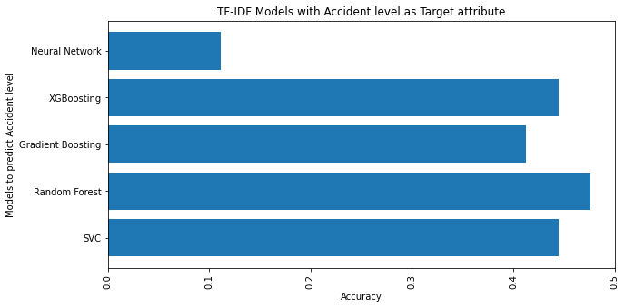

```python
# Displaying the accuracy of each model trained for the 'Accident Level' attribute using Count Vectorizer
models_list1 = ["SVC", "Random Forest", "Gradient Boosting", "XGBoosting", "Neural Network"]
accuracy_accidentlevel1 = [acc_svc1, acc_rfc1, acc_gbc1, acc_xgb1, acc_te_nn1]

fig = plt.figure(figsize = (10, 5))
plt.barh(models_list1, accuracy_accidentlevel1)
plt.title("Count Vectorizer Models with Accident level as Target attribute")
plt.xlabel("Accuracy")
plt.xticks(rotation = 'vertical')
plt.ylabel("Models to predict Accident level")
plt.show()

# Displaying the accuracy of each model trained for the 'Potential Accident Level' attribute using Count Vectorizer
models_list2 = ["SVC", "Random Forest", "XGBoosting", "Neural Network"]
accuracy_potentialaccidentlevel2 = [acc_svc2, acc_rfc2, acc_xgb2, acc_te_nn2]

fig = plt.figure(figsize = (10, 5))
plt.barh(models_list2, accuracy_potentialaccidentlevel2)
plt.title("Count Vectorizer Models with Potential Accident level as Target attribute")
plt.xlabel("Accuracy")
plt.xticks(rotation = 'vertical')
plt.ylabel("Models to predict Potential Accident level")
plt.show()

# Displaying the accuracy of each model trained for the 'Accident Level' attribute using TF-IDF Vectorizer
models_list3 = ["SVC", "Random Forest", "Gradient Boosting", "XGBoosting", "Neural Network"]
accuracy_accidentlevel3 = [acc_svc3, acc_rfc3, acc_gbc3, acc_xgb3, acc_te_nn3]

fig = plt.figure(figsize = (10, 5))
plt.barh(models_list3, accuracy_accidentlevel3)
plt.title("TF-IDF Models with Accident level as Target attribute")
plt.xlabel("Accuracy")
plt.xticks(rotation = 'vertical')
plt.ylabel("Models to predict Accident level")
plt.show()

# Displaying the accuracy of each model trained for the 'Potential Accident Level' attribute using TF-IDF Vectorizer
models_list4 = ["SVC", "Random Forest", "Gradient Boosting", "XGBoosting", "Neural Network"]
accuracy_accidentlevel4 = [acc_svc4, acc_rfc4, acc_gbc4, acc_xgb4, acc_te_nn4]

fig = plt.figure(figsize = (10, 5))
plt.barh(models_list4, accuracy_accidentlevel4)
plt.title("TF-IDF Models with Accident level as Target attribute")
plt.xlabel("Accuracy")
plt.xticks(rotation = 'vertical')
plt.ylabel("Models to predict Accident level")
plt.show()
```

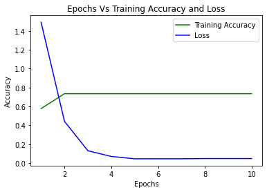

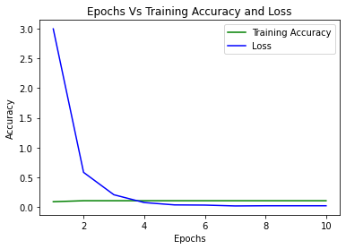

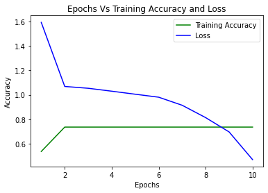

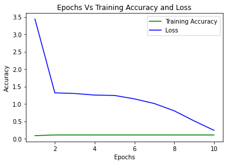

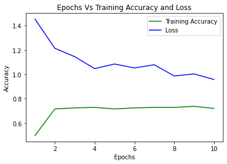

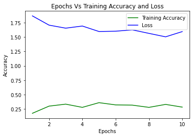

```python
# Displaying the epochs vs accuracy of Neural Network model for the 'Accident Level' attribute using Count Vectorizer
epochs = range(1,11)
plt.plot(epochs, training_history1.history['accuracy'], 'g', label='Training Accuracy')
plt.plot(epochs, training_history1.history['loss'], 'b', label='Loss')
plt.title('Epochs Vs Training Accuracy and Loss')
plt.xlabel('Epochs')
plt.ylabel('Accuracy')
plt.legend()
plt.show()

# Displaying the epochs vs accuracy of Neural Network model for the 'Potential Accident Level' attribute using Count Vectorizer
epochs = range(1,11)
plt.plot(epochs, training_history2.history['accuracy'], 'g', label='Training Accuracy')
plt.plot(epochs, training_history2.history['loss'], 'b', label='Loss')
plt.title('Epochs Vs Training Accuracy and Loss')
plt.xlabel('Epochs')
plt.ylabel('Accuracy')
plt.legend()
plt.show()

# Displaying the epochs vs accuracy of Neural Network model for the 'Accident Level' attribute using TF-IDF
epochs = range(1,11)
plt.plot(epochs, training_history3.history['accuracy'], 'g', label='Training Accuracy')
plt.plot(epochs, training_history3.history['loss'], 'b', label='Loss')
plt.title('Epochs Vs Training Accuracy and Loss')
plt.xlabel('Epochs')
plt.ylabel('Accuracy')
plt.legend()
plt.show()

# Displaying the epochs vs accuracy of Neural Network model for the 'Potential Accident Level' attribute using TF-IDF
epochs = range(1,11)
plt.plot(epochs, training_history4.history['accuracy'], 'g', label='Training Accuracy')
plt.plot(epochs, training_history4.history['loss'], 'b', label='Loss')
plt.title('Epochs Vs Training Accuracy and Loss')
plt.xlabel('Epochs')
plt.ylabel('Accuracy')
plt.legend()
plt.show()

# Displaying the epochs vs accuracy of LSTM model for the 'Accident Level' attribute using Word2Vec
epochs = range(1,11)
plt.plot(epochs, training_history5.history['accuracy'], 'g', label='Training Accuracy')
plt.plot(epochs, training_history5.history['loss'], 'b', label='Loss')
plt.title('Epochs Vs Training Accuracy and Loss')
plt.xlabel('Epochs')
plt.ylabel('Accuracy')
plt.legend()
plt.show()

# Displaying the epochs vs accuracy of LSTM model for the 'Potential Accident Level' attribute using Word2Vec
epochs = range(1,11)
plt.plot(epochs, training_history6.history['accuracy'], 'g', label='Training Accuracy')
plt.plot(epochs, training_history6.history['loss'], 'b', label='Loss')
plt.title('Epochs Vs Training Accuracy and Loss')
plt.xlabel('Epochs')
plt.ylabel('Accuracy')
plt.legend()
plt.show()
```

```python
#saving models onto the disk
model1.save("Neural_Network_Accident_Level.h5")
model2.save("Neural_Network_Potential_Accident_Level.h5")
```

## CHATBOT INTEGRATION WITH DATASET

```python
data_raw.columns
```

```
Index(['Date', 'Country', 'City', 'Industry Sector', 'Accident Level',
       'Potential Accident Level', 'Gender', 'Employee or Third Party',
       'Critical Risk', 'Description', 'Processed_Description'],
      dtype='object')
```

```python
data_raw.head()
```

|  | Date | Country | City | Industry Sector | Accident Level | Potential Accident Level | Gender | Employee or Third Party | Critical Risk | Description | Processed_Description |
| --- | --- | --- | --- | --- | --- | --- | --- | --- | --- | --- | --- |
| 0 | 2016-01-01 | 1 | 1 | Mining | 1 | 4 | Male | Third Party | Pressed | While removing the drill rod of the Jumbo 08 f... | while removing drill rod jumbo maintenance sup... |
| 1 | 2016-01-02 | 2 | 2 | Mining | 1 | 4 | Male | Employee | Pressurized Systems | During the activation of a sodium sulphide pum... | during activation sodium sulphide pump piping ... |
| 2 | 2016-01-06 | 1 | 3 | Mining | 1 | 3 | Male | Third Party (Remote) | Manual Tools | In the sub-station MILPO located at level +170... | substation milpo located level collaborator ex... |
| 3 | 2016-01-08 | 1 | 4 | Mining | 1 | 1 | Male | Third Party | Others | Being 9:45 am. approximately in the Nv. 1880 C... | being approximately personnel begin task unloc... |
| 4 | 2016-01-10 | 1 | 4 | Mining | 4 | 4 | Male | Third Party | Others | Approximately at 11:45 a.m. in circumstances t... | approximately am circumstance mechanic anthony... |

```python
# from sklearn.feature_extraction.text import TfidfVectorizer

# tfidf_vec = TfidfVectorizer(ngram_range=(1,2))
# Xt = tfidf_vec.fit_transform(X).toarray()
print(Xt)
```

```
[[0. 0. 0. ... 0. 0. 0.]
 [0. 0. 0. ... 0. 0. 0.]
 [0. 0. 0. ... 0. 0. 0.]
 ...
 [0. 0. 0. ... 0. 0. 0.]
 [0. 0. 0. ... 0. 0. 0.]
 [0. 0. 0. ... 0. 0. 0.]]
```

```python
# desc_text = data_raw['description_processed'].to_list()
# tfidf_vectorizer = TfidfVectorizer(ngram_range=(1,2))
# desc_vect = tfidf_vectorizer.fit_transform(desc_text)
```

```python
GREETING_INPUTS = ("hello", "hi", "greetings", "sup", "what's up","hey")
GREETING_RESPONSES = ["Hi", "Hey", "Hi There", "Hello", "I am glad! You are talking to me"]
def greeting(sentence):

    for word in sentence.split():
        if word.lower() in GREETING_INPUTS:
            return random.choice(GREETING_RESPONSES)

GOODBYE_INPUTS= ("bye", "see you later", "goodbye", "nice chatting to you, bye", "till next time")
GOODBYE_RESPONSES = ("See you!", "Have a nice day", "Bye! Come back again soon.")

def goodbye(sentence):
    for word in sentence.split():
        if word.lower() in GOODBYE_INPUTS:
            return random.choice(GOODBYE_RESPONSES)

BOTNAME_INPUTS = ("what is your name?","what should I call you?","name")
BOT_RESPONSES = "Hey!I'm Mercy Bot"

def botname(sentence):
    for word in sentence.split():
        #print(word)
        if word.lower() in BOTNAME_INPUTS:
            return BOT_RESPONSES

HELP_INPUTS = ("how you could help me?", "what help you provide?", "how you can be helpful?","how can you help me?",
              "what do you do?","help","what can you do?")
HELP_RESPONSE= "I am a Mercy Bot and I can help you with the description of specific industrial accidents that you would like to know. This basically helps in warning people about the conditions that led to severe accidents earlier."

def help(sentence):
    for word in sentence.split():
        if word.lower() in HELP_INPUTS:
            return HELP_RESPONSE

THANKS_INPUTS = ("thank you","thanks")
THANKS_RESPONSE = ("Glad to help","You'r welcome!","My Pleasure:)")
def bye(sentence):
    for word in sentence.split():
        if word.lower() in THANKS_INPUTS:
            return random.choice(THANKS_RESPONSE)
```

```python
from sklearn.metrics.pairwise import cosine_similarity
import random

def response(user_response):
    robo_response=''
    #user_response = "What happened to Mr. Emerson?"

    desc_text = data_raw['Processed_Description'].to_list()
    desc_text.append(user_response)

    tfidf_vectorizer = TfidfVectorizer(ngram_range=(1,2))
    desc_vect = tfidf_vectorizer.fit_transform(desc_text)
    #user_vect =  tfidf_vectorizer.fit_transform(user_response)

    vals = cosine_similarity(desc_vect[-1], desc_vect)
    idx=vals.argsort()[0][-2]
    flat = vals.flatten()
    flat.sort()
    req_tfidf = flat[-2]
    if(req_tfidf==0):
        robo_response=robo_response+"I am sorry! I don't understand you"
        #print(robo_response)
        desc_text.remove(user_response)
        return robo_response
    else:
        print(idx)
        warnings = ["Please be aware of such scenarios. Your life is precious!!","Your life is precious. Please be very cautious while performing such tasks."]
        robo_response = "As per the previous records, "+data_raw['Description'][idx] + "\n\n" + random.choice(warnings)
        #print(robo_response)
        desc_text.remove(user_response)
        return robo_response
```

```python
def bot_reply(user_response):
    user_response=user_response.lower()

    if(goodbye(user_response)!=None):

        return (goodbye(user_response))
    else:
        if(greeting(user_response)!=None):
            return (greeting(user_response))

        elif(botname(user_response)!=None):
            return (botname(user_response))

        elif(help(user_response)!=None):
            return (help(user_response))

        elif(bye(user_response)!=None):
            return (bye(user_response))

        else:
            #print("ROBO: ",end="")
            return( response(user_response))
            #sent_tokens.remove(user_response)
```

## SAMPLE QUESTIONS ANSWERED BY THE CHATBOT

1. Hello
2. what is your name
3. How can you help me
4. What happened to Mr. Emerson?
5. how can griff wrench harm us?
6. can you describe accident related to volumetric ballon
7. can you describe accident related to hot water

## CHATBOT GUI

```python
from tkinter import *

BG_WHITE = "#FFFFFF"#"#ABB2B9"
BG_COLOR = "#17202A"
TEXT_COLOR="#EAECEE"
BG_GRAY = "#ABB2B9"
FONT="Helvetica 14"
FONT_BOLD = "Helvetica 13 bold"
BOT_NAME = "MERCY"

class ChatApplication:

    def __init__(self):
        self.window = Tk()
        self._setup_main_window()

    def run(self):
        self.window.mainloop()


    def _setup_main_window(self):
        self.window.title("Chat")
        self.window.resizable(width=False,height=False)
        self.window.configure(width=1400,height=800,bg=BG_COLOR)

        #HEAD LABEL
        head_label=Label(self.window,bg=BG_COLOR,fg=TEXT_COLOR,text="WELCOME",
                         font="FONT_BOLD",pady=10)
        head_label.place(relwidth=1)

        #tiny divider
        line = Label(self.window,width=450,bg = BG_GRAY)
        line.place(relwidth=1,rely=0.07,relheight=0.012)

        #text widget
        self.text_widget = Text(self.window,width=20,height=2,bg="#008080",fg=TEXT_COLOR,
                                font=FONT,padx=5,pady=5)
        self.text_widget.place(relheight=0.745,relwidth = 1,rely=0.08)
        self.text_widget.configure(cursor="arrow",state=DISABLED)

#         #scroll bar
#         scrollbar = Scrollbar(self.text_widget)
#         scrollbar.place(relheight=1,relx=0.947)
#         scrollbar.configure(command=self.text_widget.yview)

        #bottom label
        bottom_label = Label(self.window,bg=BG_GRAY,height=80)
        bottom_label.place(relwidth=1,rely=0.825)

        #message entry box
        self.msg_entry = Entry(bottom_label,bg = "#808000",fg=TEXT_COLOR,font=FONT)
        self.msg_entry.place(relwidth=0.74,relheight=0.06,rely=0.008,relx=0.011)
        self.msg_entry.focus()
        self.msg_entry.bind("<Return>",self._on_enter_pressed)

        #send button
        send_button = Button(bottom_label,text="Send",font=FONT_BOLD,width=20,bg="#0000FF",
                             command=lambda: self._on_enter_pressed(None))
        send_button.place(relx=0.77,rely=0.008,relheight=0.06,relw=0.22)


    def _on_enter_pressed(self,event):
        msg = self.msg_entry.get()
        self._insert_message(msg,"You")

    def _insert_message(self,msg,sender):
        if not msg:
            return

        self.msg_entry.delete(0,END)

        #display user's message
        msg1= f"{sender}:{msg}\n\n"
        self.text_widget.configure(state=NORMAL)
        self.text_widget.insert(END,msg1)
        self.text_widget.configure(state=DISABLED)

        #display bot's message
        #text = "Hi!,My name is Mercy and I am kind enough to prevent you from harmful accidents:)"
        bot_response = bot_reply(msg)
        msg1= f"{BOT_NAME}:{bot_response}\n\n"
        self.text_widget.configure(state=NORMAL)
        self.text_widget.insert(END,msg1)
        self.text_widget.configure(state=DISABLED)

        self.text_widget.see(END)



#if __name__ == "__main__":
app = ChatApplication()
app.run()
```

```
6
```

# Future scope of study

1. Collect more data</br> Currently there are 425 records. This count is not sufficient to train the models. Having more data will allow better accuracy of results</br>
2. Collect additional information about the accidents</br> Additional information about the equipment that led to the accident, such as equipment name, voltage passed to the equipment, temperature of the equipment at the time of accident, will greatly help in predicting a wider range of incidents and the accuracy of the model will also be higher
3. Use Named Entity Recognition</br> Having NER will allow us identify equipments that led to accident or the persons involved in the accident
4. Sentiment analysis</br> Sentiment analysis can be used to detect the severity of the accident description and assign relevant accident level or potential accident level</br>